# julia言語 入門

## 辞書(ハッシュ)

- Dict{K,V}(key::Array{K}, value::Array{V})
- [key => value]

```python
Dict(["a", "b"], [1, 2])
```

```
Dict{ASCIIString,Int64} with 2 entries:
  "b" => 2
  "a" => 1
```

```python
# zipは二つの配列をくっつける
println(zip(["a", "b", "c"], [1, 2, 3]))

# zipされた配列からDictを作成
Dict(zip(['a':'z'], [1:26]))
```

```
Zip2{Array{ASCIIString,1},Array{Int64,1}}(ASCIIString["a","b","c"],[1,2,3])
```

```
Dict{Char,Int64} with 26 entries:
  'd' => 4
  'y' => 25
  'b' => 2
  'e' => 5
  'r' => 18
  'm' => 13
  'k' => 11
  'z' => 26
  'f' => 6
  'h' => 8
  'w' => 23
  'g' => 7
  't' => 20
  'n' => 14
  'v' => 22
  'o' => 15
  'x' => 24
  'u' => 21
  'c' => 3
  'p' => 16
  'q' => 17
  'a' => 1
  'l' => 12
  'j' => 10
  'i' => 9
  ⋮   => ⋮
```

```python
# リテラルによる作成も可能
["a" => 1, "b" => 2]
```

```
Dict{ASCIIString,Int64} with 2 entries:
  "b" => 2
  "a" => 1
```

### 乱数（パッケージの利用)

- 基本的な乱数関数はrand,randn,randperm
- 乱数発生には外部ライブラリの **Distributions** がよく用いられる
- パッケージ管理は、REPLで行えます。
  - パッケージの追加
    - Pkg.add("パッケージ名")
    - Pkg.clone("GitHubのURL")
  - buildが必要になる場合  
    Pkg.build("パッケージ名")
  - juliaを再インストールした時などに復元
    - Pkg.build()
  - パッケージの削除
    - Pkg.rm("パッケージ名")

```python
# パッケージの利用
# usingによりモジュールからexportされた関数や型などが展開される
# モジュールについては後述
using Distributions

# しーど(めるせんぬついすたの）
srand(1)

#乱数(0<= x <= 1)
B = rand(2,3) # 2*3 のランダム行列

#標準正規分布から
C = randn(3,2)

# Dirichlet分布から
D = rand(Dirichlet([1/3,1/6,1/2]),10)

println(B); println(C); println(D)
```

```
[0.23603334566204692 0.3127069683360675 0.4886128300795012
 0.34651701419196046 0.00790928339056074 0.21096820215853596]
[2.2950878238373105 0.43142152642291204
 -2.2670863488005306 0.5837082875687786
 0.5299655761667461 0.9632716050381906]
[0.21277253533777463 0.001000859375057058 0.027248365478613413 0.0033819053335193603 0.3482953059346332 0.7749392671700108 0.9995441930061966 0.4858778629241941 0.08677936410591566 0.4876184485416111
 0.00243919580373957 0.9858183978966831 0.4337065935036209 0.22244753353768967 0.5104470888147734 0.00023445232755605082 1.8774113409422723e-6 0.09628912314352274 0.0002628026054345653 0.006295233499567427
 0.7847882688584857 0.013180742728259994 0.5390450410177656 0.7741705611287909 0.14125760525059328 0.22482628050243317 0.0004539295824623991 0.41783301393228306 0.9129578332886498 0.5060863179588214]
```

### [Task](http://julia.readthedocs.org/en/latest/manual/control-flow/#tasks-and-events)(コルーチン)

コルーチンとは,処理をいったん中断し,その後必要に応じてにその処理の続きから再開することができる制御構造です

- produce  
  処理を中断する(指定する)
- Task  
  タスクを生成する
- consum  
  タスクを再開する

[パラレル](http://julia.readthedocs.org/en/latest/manual/parallel-computing/#man-parallel-computing)化する際にも似た様な制御構造を利用しています

```python
function producer()
    produce("start")
    for n=1:4
        produce(2n)
    end
    produce("stop")
end;

p = Task(producer);
```

```python
#何度か更新 "start" -> 2->4->6...と更新されていきます。
println(consume(p))
println(consume(p))
println(consume(p))
println(consume(p))
println(consume(p))
println(consume(p))
println(consume(p))
println(consume(p))
```

```
start
2
4
6
8
stop
()
()
```

#### コルーチンを使ってギブスサンプラーを作ってみよう!!

```python
# 初回実行時はPkg.add("Distributions")で
# Distributionsパッケージをインストールしておく
using Distributions

#平均[0, 0], 分散[1 ρ; ρ 1] の場合
ρ = 0.90
μ = [0, 0]
S  = [1 ρ; ρ 1]
Sⁱ = inv(S)
detS = det(S)

#目的関数
f(x) = exp(-(x-μ)'Sⁱ*(x-μ)/2)/(2π*sqrt(detS))
```

```
f (generic function with 1 method)
```

- ギブスサンプリング
  - 同時分布においてサンプルしたい確率変数を除いた確率変数に条件付けされた分布からのサンプルを繰り返すことで目的とする分布からのサンプルを得る手法
  - xのサンプルはp(x | y)から、yのサンプルはp(y | x)からサンプリング
  - 平均ベクトル$\mu=[0, 0]^T$、共分散行列の対角項が1, 共分散項が$\rho$のとき$p(x|y)=N(\rho y, 1 - \rho^2)$

```python
#条件付き分布から一つサンプリング
function sample_one(x)
    new_x = rand(Normal(ρ*x[2], 1-ρ^2))
    new_y = rand(Normal(ρ*new_x, 1-ρ^2))
    return [new_x, new_y]
end

#コルーチン
function sampler(burnin)
  x = zeros(2)
  # BURNINの期間はひたすらサンプルを繰り返すのみで値は返さない
  for i = 1:burnin
    x = sample_one(x)
  end
  while true
    x = sample_one(x)
    produce(x)  #produce
  end
end
```

```
sampler (generic function with 1 method)
```

```python
#イテレーション回数
N = 600
BURNIN = 0

xs, ys = zeros(N), zeros(N)  # 0埋めされたN次元ベクトルの生成

#コルーチン作成
sim = @task sampler(BURNIN)

#ループで任意回数サンプルします
for i = 1:N
  xs[i], ys[i] = consume(sim)
end
```

```
INFO: Loading help data...
```

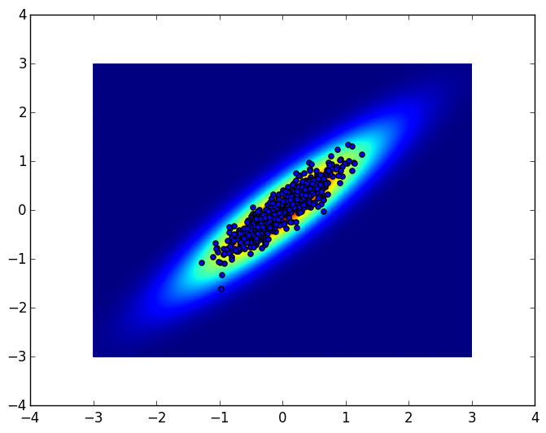

```
PyObject <matplotlib.collections.PathCollection object at 0x13b419d10>
```

```python
# Pythonのmatplotlibを呼び出す
# 初回実行時は事前にPkg.add("PyPlot")しておく
using PyPlot

ls = linspace(-3., 3., 1000) # -3.0〜3.0の区間の点を1000点生成

Zs = Float64[f([x, y])[1] for x = ls, y = ls]  # 目的関数から分布を計算
pcolor(ls, ls, Zs, alpha=0.5)  # 分布の描画

scatter(xs, ys)  # サンプリングした点をプロット
```

## 関数

```python
#関数定義は以下のように可能
function f(x::Int64,y::Int64)
    x + y
end
f(x::Float64, y::Float64) = x * y
f(x::Int64, y::Float64) = x / y
f(x,y) = x - y
```

```
f (generic function with 5 methods)
```

```python
f(1.,2) # 1 - 2
```

```
-1.0
```

```python
#可変長引数 -> タプル型が渡されます
foo(arg...) = arg
foo(1,2,3)
```

```
(1,2,3)
```

```python
#オプショナル引数#デフォルト引数
foo(x,y=2,z=3) = (x,y,z)

foo(1,5,10.) # ->(1,5,10.)
```

```
(1,5,10.0)
```

```python
#デフォルト値が返されました
foo(10)
```

```
(10,2,3)
```

```python
#名前付き引数 (`;` セミコロン)
foo(x::Int ;y=10, z = "test") = println(x,y,z)

foo(10,y = 20, z = "Test")
```

```
1020Test
```

```python
# オプショナル引数と名前付き引数の違いは？
foobar(x, y = 2, z = 3) = (x, y, z)  # オプショナル引数

# オプショナル引数に対してはキーワード指定ができない
println(foobar(1, y=3, z=4))
```

```
function foobar does not accept keyword arguments
while loading In[36], in expression starting on line 5
```

```python
hoge(x; y = 2, z = 3) = (x, y, z)  # 名前付き引数

# これは可能
println(hoge(1, y=3, z=4))
```

```
(1,3,4)
```

### 無名関数

- (x, y) -> 関数本体
- do 構文
  - do構文は、無名関数を作る
  - 第一引数が関数型である関数に対してはdo構文を用いることによってdo以下に関数本体を書くことができる

```python
# モンテカルロ積分で円周率を計算
N = 100000

# (x,y)->x^2+y^2 は無名関数!
# rand(N)は[0, 1)の一様乱数をN点生成
ps1 = map((x,y) -> x^2+y^2<=1, rand(N),rand(N))
ps2 = map(rand(N),rand(N)) do x,y
    x^2 + y^2 <= 1
end

# ps1, ps2は真偽値のベクトルであるがtrueが1, falseが0に評価されるのでsumを取るとtrueの数を数える
# これは第一象限に対する和となるので4倍することで全象限分の和となる
println(4 * sum(ps1) / N)
println(4 * sum(ps1) / N)
```

```
3.14244
3.14244
```

#### マクロを搭載

- **_@_**から始まるものは、_*マクロ*_と呼ばれるものです。
- ストリングスタイプのマクロも存在
  - 正規表現リテラルのように使える** r" "**もマクロ
    - match(r"^(?:#|$)", "# a comment")
  - バージョン文字列を表すマクロ`v"1.2.3"`やバイナリ文字列を表すマクロ`b"DATA\xff\u2200"`なども存在
- juliaのマクロは、Lisp like のかなり強力なものが搭載されています。

```python
@which f(2,1) #どのメソッドが呼ばれたかを知るためのマクロ。
```

f(x::**Int64**,y::**Int64**) at In[30]:3

```python
@time f(3.,4)
```

```
elapsed time: 0.001163786 seconds (13896 bytes allocated)
```

```
-1.0
```

### 低レベルコードの出力

- 与えられた引数と型名にマッチする関数のASTやLLVMバイトコード、ネイティブコードを出力可能
- code_lowered
  - 低レベルASTの出力
- code_typed
  - 型推論された低レベルASTの出力
- code_llvm
  - LLVMバイトコードの出力
- code_native
  - ネイティブコードの出力

```python
hello(name::String) = "Hello, $name"

#低級なこーど
code_lowered(hello, (String,))
```

```
1-element Array{Any,1}:
 :($(Expr(:lambda, {:name}, {{},{{:name,:Any,0}},{}}, :(begin  # In[41], line 1:
        return (top(string))("Hello, ",name)
    end))))
```

```python
#型付けられたこーど
code_typed(hello, (String,))
```

```
1-element Array{Any,1}:
 :($(Expr(:lambda, {:name}, {{},{{:name,String,0}},{}}, :(begin  # In[41], line 1:
        return (top(string))("Hello, ",name::String)::Union(UTF8String,ASCIIString)
    end::Union(UTF8String,ASCIIString)))))
```

```python
#以下を用いるとllvm-ir出力しますたぶん。（実際実行されるものと違う場合かもです)
code_llvm(hello, (String,))
```

```
define %jl_value_t* @julia_hello_22834(%jl_value_t*, %jl_value_t**, i32) {
top:
  %3 = alloca [4 x %jl_value_t*], align 8
  %.sub = getelementptr inbounds [4 x %jl_value_t*]* %3, i64 0, i64 0
  %4 = getelementptr [4 x %jl_value_t*]* %3, i64 0, i64 2, !dbg !8582
  store %jl_value_t* inttoptr (i64 4 to %jl_value_t*), %jl_value_t** %.sub, align 8
  %5 = load %jl_value_t*** @jl_pgcstack, align 8, !dbg !8582
  %6 = getelementptr [4 x %jl_value_t*]* %3, i64 0, i64 1, !dbg !8582
  %.c = bitcast %jl_value_t** %5 to %jl_value_t*, !dbg !8582
  store %jl_value_t* %.c, %jl_value_t** %6, align 8, !dbg !8582
  store %jl_value_t** %.sub, %jl_value_t*** @jl_pgcstack, align 8, !dbg !8582
  store %jl_value_t* null, %jl_value_t** %4, align 8
  %7 = getelementptr [4 x %jl_value_t*]* %3, i64 0, i64 3
  store %jl_value_t* null, %jl_value_t** %7, align 8
  %8 = icmp eq i32 %2, 1, !dbg !8582
  br i1 %8, label %ifcont, label %else, !dbg !8582

else:                                             ; preds = %top
  call void @jl_error(i8* getelementptr inbounds ([26 x i8]* @_j_str0, i64 0, i64 0)), !dbg !8582
  unreachable, !dbg !8582

ifcont:                                           ; preds = %top
  %9 = load %jl_value_t** %1, align 8, !dbg !8582
  store %jl_value_t* inttoptr (i64 140636214751424 to %jl_value_t*), %jl_value_t** %4, align 8, !dbg !8583
  store %jl_value_t* %9, %jl_value_t** %7, align 8, !dbg !8583
  %10 = call %jl_value_t* @jl_apply_generic(%jl_value_t* inttoptr (i64 140636736931200 to %jl_value_t*), %jl_value_t** %4, i32 2), !dbg !8583
  %11 = load %jl_value_t** %6, align 8, !dbg !8583
  %12 = getelementptr inbounds %jl_value_t* %11, i64 0, i32 0, !dbg !8583
  store %jl_value_t** %12, %jl_value_t*** @jl_pgcstack, align 8, !dbg !8583
  ret %jl_value_t* %10, !dbg !8583
}
```

```python
#ネイティブコード
code_native(hello, (String,))
```

```
	.section	__TEXT,__text,regular,pure_instructions
Filename: In[41]
Source line: 1
	push	RBP
	mov	RBP, RSP
	push	RBX
	sub	RSP, 40
	mov	QWORD PTR [RBP - 40], 4
Source line: 1
	movabs	RBX, 4343823312
	mov	RAX, QWORD PTR [RBX]
	mov	QWORD PTR [RBP - 32], RAX
	lea	RAX, QWORD PTR [RBP - 40]
	mov	QWORD PTR [RBX], RAX
	xorps	XMM0, XMM0
	movups	XMMWORD PTR [RBP - 24], XMM0
	cmp	EDX, 1
	jne	69
	lea	RAX, QWORD PTR [RBP - 24]
	mov	RCX, QWORD PTR [RSI]
	movabs	RDX, 140636214751424
Source line: 1
	mov	QWORD PTR [RBP - 24], RDX
	mov	QWORD PTR [RBP - 16], RCX
	movabs	RCX, 4330270464
	movabs	RDI, 140636736931200
	mov	RSI, RAX
	mov	EDX, 2
	call	RCX
	mov	RCX, QWORD PTR [RBP - 32]
	mov	QWORD PTR [RBX], RCX
	add	RSP, 40
	pop	RBX
	pop	RBP
	ret
Source line: 1
	movabs	RAX, 4330288112
	movabs	RDI, 4370677776
	call	RAX
```

## メタプログラミング

簡単なマクロの定義と機能を載せておきます。  
コード自体をオブジェクトとして扱うものを同図像性(Homoiconicity)と呼びます。 juliaのマクロは、Lispと同じように抽象構文木をレベルで操作が可能です。

```python
# まず文字列を用意
prog = "1 + 1"
```

```
"1 + 1"
```

```python
# 文字列型をexpressionと呼ばれるオブジェクトにパース
ex1 = parse(prog)
```

```
:(1 + 1)
```

```python
# juliaではexpressionはExpr型で表せられます。
typeof(ex1)
```

```
Expr
```

```python
# :callは(expression)が持つ識別子だと思ってください.
# :callの他にも、:function :for :block :if ...など様々なものがあります。
ex1.head
```

```
:call
```

```python
#:call や ':'が接頭するものは,シンボルと呼ばれる型を表します
#シンボルは以下のように定義もできます。
:A
```

```
:A
```

```python
# 内部のargumentはシンボル, expressionまたはリテラルです。
ex1.args
```

```
3-element Array{Any,1}:
  :+
 1
 1
```

```python
# expressionはシンボルと同様に定義することもできます
:(a + b*c + 1)  ==
parse("a + b*c + 1") ==
Expr(:call, :+, :a, Expr(:call, :*, :b, :c), 1)
```

```
true
```

```python
# 複数行に渡るExprの定義ではquoteを用います
ex5 = quote
    x = 1
    y = 2
    x + y
end
```

```
quote  # In[52], line 3:
    x = 1 # line 4:
    y = 2 # line 5:
    x + y
end
```

```python
# dump関数を用いるとExprの内容が一覧できます
dump(ex1)
```

```
Expr
  head: Symbol call
  args: Array(Any,(3,))
    1: Symbol +
    2: Int64 1
    3: Int64 1
  typ: Any
```

```python
# Exprがネストしている場合
ex4 = parse("(4 + 4) / 2")
dump(ex4)
```

```
Expr
  head: Symbol call
  args: Array(Any,(3,))
    1: Symbol /
    2: Expr
      head: Symbol call
      args: Array(Any,(3,))
        1: Symbol +
        2: Int64 4
        3: Int64 4
      typ: Any
    3: Int64 2
  typ: Any
```

```python
#Lispが好きな人ため?に S 式での表現もサポートしています
Meta.show_sexpr(ex4)
```

```
(:call, :/, (:call, :+, 4, 4), 2)
```

### Interpoltation

- Expressionの内部で通常のjuliaのコードを処理したい場合
  - 接頭辞`$`によって処理可能

```python
#exsample
a = 1

ex = :($a + b)
```

```
:(1 + b)
```

```python
# 文字列内部に値を埋め込む際にも同様に$で展開可能
println("a = $(a)")
```

```
a = 1
```

### eval

- Exprをグローバルスコープで評価

```python
# eval 関数を用いると:Expr をグローバルスコープで実行されます。
eval(:(1 + 2))
```

```
3
```

```python
a = 1; b = 2;
eval(:(a + b))
```

```
3
```

```python
x = [1, 2]
```

```
2-element Array{Int64,1}:
 1
 2
```

```python
# xへの代入を表すExprをevalで評価
eval(:(x=1))
```

```
1
```

```python
x
#グローバルスコープで実行されました!
```

```
1
```

## マクロ

- マクロを用いることで実行を行う前に引数に対する様々な処理をすることができます。

```python
#マクロの内部では 引数　をシンボルとして処理します。
macro test(x)
    x.args
end

# :(println("x")).argsに展開される
@test (println("x"))
```

```
2-element Array{Any,1}:
 :println
 "x"
```

```python
# マクロがどのように展開されるか確認したい場合は
macro say_hello(name)
        return :( println("Hello, ", $name) )
end

# macroexpand関数を用います。
macroexpand(:(@say_hello("human")))

# コードがちゃんと書き換わってます
```

```
:(println("Hello, ","human"))
```

### なぜマクロが必要なのか

```python
# Exprを引数に持ち返り値もExprである関数(マクロではない)
function math_expr(op, op1, op2)
    expr = Expr(:call, op, op1, op2)
    return expr
end
ex = math_expr(:+, 1, Expr(:call, :*, 4, 5))
```

```
:(1 + 4 * 5)
```

```python
eval(ex)
```

```
21
```

### juliaにおけるコードの評価

- 以上のようにExpressonを引数に持ち返り値もExpressonであるような関数を定義してもいいのではないかと思うかもしれない
- しかしマクロを使うメリットはコードの変換・生成にある
  - juliaにおけるコード評価は大雑把に２種類の段階を踏む,第一段階ではrawコードの解析(パース)を行う、そして第二段階で、実行を行う。
  - メタプログラミングを使うことで、第一段階が終わった段階のコードに対してコードの変換・生成を行うことができる。
  - それにより、ネイティブなjuliaのコードと同じ速度で実行が可能となっている、そのために、マクロは必要なのだ。 たぶん

```python
#ex
macro twostep(arg)
    println("I execute at parse time. The argument is: ", arg)

    return :(println("I execute at runtime. The argument is: ", $arg))
end

ex = macroexpand( :(@twostep :(1, 2, 3)) );
```

```
I execute at parse time. The argument is: :((1,2,3))
```

```python
typeof(ex)
```

```
Expr
```

```python
ex
```

```
:(println("I execute at runtime. The argument is: ",$(Expr(:copyast, :(:((1,2,3)))))))
```

```python
eval(ex)
```

```
I execute at runtime. The argument is: (1,2,3)
```

```python
#macroの例
macro assert(ex)
    return :($ex ? nothing : error("Assertion failed: ", $(string(ex))))
end
```

[(type-trait)](https://github.com/abeschneider/TypeTraits.jl)はマクロの使い方がわかりやすいサンプルです

### コードジェネレーション

似たようなコードを何度も書くのはめんどくさい,だけどやらなきゃならない時  
基本的なところは上記とほとんど同じです.

四則演算などを一気に定義します。

```python
#メソッドが上書きされるので気をつけて下さい
for op = (:+, :*, :&, :|, :$)
  eval(quote
    ($op)(a,b,c) = ($op)(($op)(a,b),c)
  end)
end

#もう少し簡略化して書くと
for op = (:+, :*, :&, :|, :$)
  eval(:(($op)(a,b,c) = ($op)(($op)(a,b),c)))
end

#eval(quote(...))をマクロをつかって表現すると
for op = (:+, :*, :&, :|, :$)
  @eval ($op)(a,b,c) = ($op)(($op)(a,b),c)
end
```

```python
#最後にストリングスタイプのマクロについてです。
#定義は macro <name>_str(x) ~ end

macro ♥‿♥_str(s)
    "I LOVE $(uppercase(s))"
end

#呼び出しは <name>""です。

♥‿♥"Julia"
```

```
"I LOVE JULIA"
```

- [ここ](http://iaindunning.com/2014/julia-unicode.html)を参考にしました
- 爆発"Julia"

## IO

open  
read  
write

など、一般的な出入力を備えています。

[ここ](http://julia.readthedocs.org/en/latest/manual/networking-and-streams/)が詳しいです。

## Rのデータフレームに似たライブラリ

### DataFrames

- 入出力はこれを使うと便利です。
- 導入はPkg.add("DataFrames")
- 他にも,音声、画像などデータを扱うためのライブラリがあります。
  - 一番最後にまとめてあるので暇なら見てみてください。  
    ___

```python
# いろいろな入力関数
#CSVファイルの読み込み
readcsv

#ファイルを全て読む
readall

#一行づつ読み込む
readline

#改行を削除して読み込みます
readchomp
```

```
readchomp (generic function with 1 method)
```

```python
#  cdに存在するファイルやディレクトリをArray{String}で返します. (lsコマンドのようなもの)
println(readdir())
#  cdのパスをかえします。
println(pwd())
```

```
Union(UTF8String,ASCIIString)[".ipynb_checkpoints","convert.sh","julia言語入門.html","julia言語入門.ipynb","julia言語入門.slides.html","outfile","reveal.js"]
/Users/wrist/work/julia/MLJulia/Introduction_to_Julia
```

### do構文を使ったI/O処理

```python
data = "こんにちは"
# 自動的にクローズする、pythonでいうところのwith open
open("outfile", "w") do io
    write(io, data)
end
```

```
15
```

```python
# run(`...`)でシェルコマンドの実行
run(`cat outfile`)
```

```
こんにちは
```

```python
#=上記のopenは以下によって定義されています。
function open(f::Function, args...)
    io = open(args...)
    try
        f(io)
    finally
        close(io)
    end
end
=#
# do構文を使うことで第一引数のfを外側のdo〜endの間に書ける

# outfileをすべて読み込む
data = readall("outfile")
```

```
"こんにちは"
```

## モジュール

- pythonとは違い、module ~ end により定義される。
  - pythonはファイル単位だったと思います
  - julia起動時に読み込まれるモジュールは基本的には以下
    - **Base**
    - **Core**
    - **Main**
- **Main**モジュールがワークスペースになります。 ___

```python
# 前に作ったニューラルネットワークのライブラリのモジュール定義
module Neural
# モジュールが呼ばれた時に、Mainへ展開して欲しいものを,export 以下に書く
    export Model, ANN, QNN, LQNN, quasi_newton_method, sgd, nesterov, l_bfgsNN,
            preprocess, predict, gradient, getWeights

#= importとusingの違いは以下を参照
   https://julia.readthedocs.org/en/latest/manual/modules/

   "import モジュール名"だと変数は"モジュール名.変数名"でしかアクセスできないが
   "using モジュール名"だとexportされた変数はモジュール名を付けなくてもアクセス可能 =#

# ニューラルネットのモジュールにメソッドを展開する
    import Base.show

# ライブラリをMainモジュールに展開する
# 初めて使う場合はPkg.add("NumericExtensions")しておく
    using NumericExtensions

#= require -> ファイルを Mainで展開
　 include -> ファイルを このModule内で展開 =#

    #クラス定義
    include("base.jl")
    #アクセサ・ゲッタ
    include("ann_weight.jl")
    #バック・フォワードプロパゲーション
    include("bfprop.jl")
    #確率的勾配降下法
    include("sgd_methods.jl")
    #ラインサーチ
    include("linesearch.jl")
    #ラインサーチユーティリティ
    include("linesearch_utils.jl")
    #準ニュートン法(定数定義あり)
    include("quasi_methods.jl")
    #L−BFGS
    include("l_BFGS.jl")
    #Nesterov
    include("nesterov.jl")
    #ユーティリティ
    include("utils.jl")

#ModuleEnd
end

#このような感じでライブラリが書かれている場合が多いです
```

[output not shown]

## ちょっと変わった型システム

- juliaの型(クラス)システムは、多重ディスパッチと呼ばれるものを利用し多態性を表現
  - オブジェクト指向言語ではクラス(型）にメソッド(関数)が所属
  - juliaでは、関数(メソッド)に型(クラス)が所属
    - 具体的には、関数の引数の型によって、関数の挙動が変化
      - 関数のオーバーロードに近い形のものを想像してくださいです

## 型

型は、大きく分けると * 抽象型  
* 具象型

に分けることができます。

- 抽象型は、変数を持つことができません!!! さらに、インスタンスも生成できません。
- 具象型は 継承できません!!

従って、**移譲(Delegation)**を使い継承関係を構築することもできます。

どうしても使いたい場合は、trait-mixin マクロなどを作ったりすることもできます。 ____

#### 型公式サイトの 目次です

### 抽象型

- **Abstruct Type**  
  抽象型の定義です

### 具象型

- **Bit Type**  
  ビット型を定義IntとかFloat64などはこの型です。  
  -- How to use --  
  定義:: bitstype «bits» «name» <: «supertype»  
  実際に使うには,少し面倒で下に少しだけ紹介してあります。
- **Composit Type**  
  pythonのクラス や Cの構造体に近いものと考えてください。
- **Immutable Composit Type**  
  不変型です、インスタンスの値::(注)を変更することができない型です。

### パラメータを含む型

- **Parametric Type**  
  パラメータを持つ型です。型に定義された、変数の型を任意の型に制限します。  
  具体的には、以下で取り扱っています。
- **Parametric Abstract Types**  
  パラメータを含んだ抽象型です。  
  Singleton Types, abstract {T}などがありす
- **Pramtric Composit Type**  
  パラメータを含んだComposit Typeです。
- **Parametric Bits Types**
- **Type Union**  
  結合型を作ります。e.g. `<Char型とStrings型>`  
  (Union(Char, String))
- **Type Aliases**  
  型のエイリアスを作ります。e.g. `(Array{T,1} == Vector{T})`  
  'typealias Vector{T} Array{T,1}'で定義します

Tuple Types

Vararg Tuple Types

“Value types”

Nullable Types: Representing Missing Values** v0.4~

### Juliaの型グラフ

```python
#Top::全ての型はAny型の子クラス,逆はNone型
level = 0
function showtypetree(subtype)
    global level
    subtypelist = filter(asubtype -> asubtype != Any, subtypes(subtype))
    if length(subtypelist) > 0
         println("\t" ^ level, subtype)
         level += 1
         map(showtypetree, subtypelist)
         level -= 1
    else
         println("\t" ^ level, subtype)
    end
end

showtypetree(AbstractArray)#Number, String, AbstractArrayを見てみたいな。
```

```
AbstractArray{T,N}
	AbstractSparseArray{Tv,Ti,N}
		SparseMatrixCSC{Tv,Ti<:Integer}
	Bidiagonal{T}
	DArray{T,N,A}
	DenseArray{T,N}
		Array{T,N}
		BitArray{N}
		SharedArray{T,N}
	Diagonal{T}
	Givens{T}
	Hermitian{T}
	HessenbergQ{T}
	Message
	QRCompactWYQ{S}
	QRPackedQ{T}
	Range{T}
		FloatRange{T<:FloatingPoint}
		OrdinalRange{T,S}
			StepRange{T,S}
			UnitRange{T<:Real}
	SubArray{T,N,A<:AbstractArray{T,N},I<:(Union(Range{Int64},Int64)...,)}
	SymTridiagonal{T}
	SymmetricRFP{T<:Union(Complex{Float64},Float32,Float64,Complex{Float32})}
	Symmetric{T}
	TriangularRFP{T<:Union(Complex{Float64},Float32,Float64,Complex{Float32})}
	Triangular{T,S<:AbstractArray{T,2},UpLo,IsUnit}
	Tridiagonal{T}
	Woodbury{T}
```

```
0
```

```python
#Bit型はこんな感じで定義します。
import Core.Intrinsics.box, Core.Intrinsics.unbox #box、unboxはかなりプリミティブな関数です。

bitstype 64 Blah64
bitstype 32 Blash32


blash64 = box(Blah64, unbox(Int, 1))
#または、型の解釈を変更する関数を用い。
blash32 = reinterpret(Blash32,uint32(8))

(blash32,blash64)
```

```
(Blash32(0x00000008),Blah64(0x0000000000000001))
```

#### クォータニオンを定義してみよう!!

```python
#=は複数行コメントアウト=#

#=
抽象型の定義
abstract Number
abstract Real     <: Number
abstract FloatingPoint <: Real
abstract Integer  <: Real
abstract Signed   <: Integer
abstract Unsigned <: Integer
=#

#具象型の定義
# T はパラメトリックタイプ(型) ・この場合 Real 以下の任意の同一の型を取る。
# <:Numberは型の親子関係を示す。
type Quaternion{T<:Real} <:Number
    x::T
    y::T
    z::T
    w::T
    #内部にもコンストラクタ(型と同一名の関数)を定義できます。詳しくは 公式サイトで確認してください。
end
#外部コンストラクタで初期値などを定義できる。
Quaternion() = Quaternion(0,0,0,0)

#具象型は他にも、不変型の immutable があります。

+(q1::Quaternion, q2::Quaternion) = Quaternion(q1.x + q2.x, q1.y + q2.y, q1.z + q2.z, q1.w + q2.w)
-(q1::Quaternion, q2::Quaternion) = Quaternion(q1.x - q2.x, q1.y - q2.y, q1.z - q2.z, q1.w - q2.w)
*(q1::Quaternion, q2::Quaternion) = Quaternion(q1.w * q2.w - q1.x * q2.x - q1.y * q2.y - q1.z * q2.z,
                                               q1.y * q2.z - q1.z * q2.y + q1.w * q2.x + q1.x * q2.w,
                                               q1.z * q2.x - q1.x * q2.z + q1.w * q2.y + q1.y * q2.w,
                                               q1.x * q2.y - q1.y * q2.x + q1.w * q2.z + q1.z * q2.w)
*(q1::Quaternion, r::Real) = Quaternion(q1.x*r, q1.y*r, q1.z*r, q1.w*r)
*(r::Real, q1::Quaternion) = *(q1,r)
```

```
* (generic function with 118 methods)
```

```python
#コンストラクタ new はいりません
q1, q2 = Quaternion(1,2,3,4), Quaternion(5,6,7,8)

q1 * q2
```

```
Quaternion{Int64}(-6,24,48,48)
```

```python
#パラメトリックタイプの型が変わり数値型はFloat64に統一されました。
#この挙動については、したで少し説明があります。
q1*0.5
```

```
Quaternion{Float64}(0.5,1.0,1.5,2.0)
```

### パラメトリックタイプで重要なことは

- ** たとえ Float64 <: Real であっても Quaternion{Float64} <: Quaternion{Real}. ではないことです。**

#### 型理論の言葉を借りると

パラメトリックな型はは共変や反変でなく不変である。

wikipediaより * 共変(covariant) :: 狭い型から,広い型へ変換すること。 * 反変(contravariant) :: 広い型から,狭い型へ変換すること。 * 不変(invariant) :: そのた

### Tuple Type

- 順序,型,imutableです。
- パラメータについては共変

```python
typeof((1, "Hello Julia", 2.))
```

```
(Int64,ASCIIString,Float64)
```

```python
(Int, String) <:(Number, Any)
```

[output not shown]

### Singleton Types

- 全ての型は,Type{T<:Top}と呼ばれるパラメータ型のインスタンス

```python
#Type{T<:Top}
#Top = Union(Any, Undef)
#唯一のインスタンスがオブジェクトTである抽象パラメタ型。
isa(Float64, Type{Float64})
```

```
true
```

## Conversion and Promotion

juliaでは上位型への暗黙的な型キャストは行いません。  
なので、型が適用できなかった場合に明示的に型変換を行う関数promoteとそれに関連したconvert関数が必要になってきます。 ____

- Promotion 上位の型への変換 ->
  - promote_rule関数によって型の変換関係が定義されています。
  - promote_type関数がpromote_ruleに基づく型の変換を行っています。
- Conversion
  - convert 関数 promote 関数が型変換を行うときに用いる関数。
  - 型変換の定義を行う場合は convert 関数に定義してください。

```python
# convert関数は一般的に二つの引数を取る
#     第一引数に目的の型
#     第二引数に変換したい型の値
# 出力は変換された型のインスタンス

convert(::Type{Bool}, x::Number) = (x!=0)
# 第一引数はシングルトン型
#     型それ自体のことです。e.g.(Int, Float64...)
# 第一引数に変数が定義されていないのは関数本体では用いないため
```

```
convert (generic function with 1 method)
```

```python
convert(Bool, 1)  # 1をBoolに変換
```

```
true
```

```python
convert(Bool,1im)  # 1imをBoolに変換
```

```
true
```

```python
# Promotionの定義の仕方
# 以下のように定義することでFloat64とFloat32の間の演算がFloat64で行われることを表す
promote_rule(::Type{Float64}, ::Type{Float32} ) = Float64
```

```
promote_rule (generic function with 1 method)
```

```python
# 共通のより大きな型を返す
promote_type(Uint64,Float32)
```

```
Float32
```

[CaseStudy](http://docs.julialang.org/en/release-0.3/manual/conversion-and-promotion/#case-study-rational-conversions)もう少しに詳しく書かれています。

さらに詳しく知りたい場合は、以下の資料がオススメです。  
juliaのコア開発者の@StefanKarpinskiさんの書かれた多重ディスパッチの[資料](http://nbviewer.ipython.org/gist/StefanKarpinski/b8fe9dbb36c1427b9f22)は素晴らしいです。  
juliaの多重ディスパッチの日本語で書かれた資料は[ここ](http://dsng.hatenablog.com/entry/2014/01/27/173154)です。  
上記を参考資料にしているのでわかりやすいです。

### 実際の処理の流れ

1. 型Tと型Sの間で何かしら計算出来ない場合はfallbackメソッドが呼ばれる
2. fallbackメソッドでpromote関数が呼ばれる
3. promote関数ではconvert(promote_type(T,S),x)が呼ばれる
4. ここでpromote_type(T,S)の返り値はpromote_ruleによって決定され、より大きな共通の型を返す
5. 返された型にxの値を変換

## 外部ライブラリ

```python
julia libraly おすすめ100選
インターフェース
  vim
  Emacs
  LightTble
  JuliaStudio
  IJulia.etc

データ関連
  MNist
    MNist
  R標準データ
    RDatasets
  経済データ
    EconDatasets
    MarketData
    Quandl
    WorldBankData
  Twitter
    Twitter
  Yepl
    Yepl

データベース
  Key-Value
    Redis
  メタライブラリ
    ODBC

IO/かんれん

  音響
	AudioIO
    WAV
  画像
    Images
    OpenCV::要Cxx
  動画
    VideoIO
  時系列データ
    TimeSeries
  csv
	DataFrames
    Pandas
  YAML
    YAML
  HDF5
    HDF5
  FASTA::DNA
    FASTA
  FITS::画像
    FISTIO
    NIfTI
    WCSLIB
  バイナリファイル
    StrPack
  地図データ
    OpenStreetMap

  RobotOS


計算関連::JuliaStats
  汎用計算ライブラリ
    StatsBase
    NumericExtentions  logsumexp
    NumericFuns
  自動微分
    AutoDiff
  微積分
    標準でガウス＝クロンロッド適応求積あり
    Calculus
  機械学習関連
    MLBase
  乱数(確率分布・密度関数.etc)
    Distributions
  正定値行列
    PDMats
  ランダム行列
    RandomMatrices

データ処理
  テキスト
    TextAnalysis
  日本語前処理
    MeCab
  連続データ(ウェーブレット変換)
    Wavelets
  音響
    WORLD

分析ツールキット
  YT

機械学習
  DeepLearning関連
    Boltzmann Machine | DBN

  CNN
    Mocha

  サンプリング
    Lora
    Manba
    Stan

  非負値行列分解
    NMF(pLSI)
  コンディショナるランダムフィールド
    CRF
  多様体学習
    ManiforldLearnig
  カーネル法
    KernelDensityEstimaition
    Libsvm
    SVM
  混合モデル
    MixturModels
  ブースティング
    XGBoost

  ベイジアンネットワーク(グラフィカルモデル)
    PGM
    BayesNet

  アンサンブル学習
    Orchestra
  経験リスク最小化
    RegERMs
  近傍法
    FLANN
  時系列モデル
    TimeModel
  トピックモデル
    TopicModels

  なんだこれ
    DirichletProssesMixtur
    Stochy

最適化計算
  進化計算
    Evolution
    Phylogenetics
  最適化
    NLopt
  最適化メタライブラリ
    Jump
  求根アルゴリズム
    Roots
  半正定値計画問題
    SemidefiniteProgramming


plot関連
  Gadfly
    アニメーション
      Reel

  PyPlot
  TextPlot
  Winston
  GR

  グラフ
    GlaphLayout
    GlaphVis
  ボロノイ図
    VoronoiDelaunary


Foreign Function Interface (FFI)
  Python
    PyCall
  C
    標準ライブラリ
  C++
    Cxx
  Java
    JavaCall
  R
    RCall
  OpenCL
    OpenCL

その他
  メモ化
    Memoise
  代数
    Quaternion
    DualNumber
    HyperDualNumber
  線形代数 (特殊な行列)
    SpechalMatrices
  チェック
    QuickCheck
  関数リアクティブ
    Reactive
  暗号化
    Sodium
  テンソルオペレーション
    TensorOperations
  非線形力学系
    CauseMap
  プログラミング言語関連
    ValueDispatch
  数値の妥当性(0.99999... = 1?)
    ValidatedNumerics
  選挙スキーム？
    Voting

GPU
juliaGPU
```

[output not shown]